# Notebook 05: Datasets - Loading, Transforming, and Visualizing Data

# Deep Dive: `collate_dict` - a Closure That Builds a Collate Function

## The Problem `collate_dict` Solves

`default_collate` gives us a batched **dict**. The training loop wants a batched **tuple** `(xb, yb)` so it can write `for xb, yb in dl:`. We need a collate function that does both: batch the samples *and* return the result as a tuple in feature order.

But notice a catch: a `DataLoader`'s `collate_fn` is called with just one argument - the list of samples. It has no idea what the feature names are. So we need to *bake in* the feature names ahead of time. That's a job for a **closure / factory function**.

## The Complete Code

```
#|export
def collate_dict(ds):
    get = itemgetter(*ds.features)     # build the getter once, from the dataset's fields
    def _f(b):                          # this is the actual collate_fn the DataLoader calls
        return get(default_collate(b))  # batch -> dict -> tuple
    return _f                           # hand back the configured collate_fn
```

`collate_dict` is a **factory**: it doesn't collate anything itself. You give it a dataset, and it *returns a custom collate function* that already knows that dataset's feature names.

## Line-by-Line

### `get = itemgetter(*ds.features)`

`ds.features` is something like `['image', 'label']`. The `*` **unpacks** that list into separate arguments, so this is `itemgetter('image', 'label')`. The result, `get`, is a getter that, applied to a dict, returns `(d['image'], d['label'])` - a tuple, in feature order.

**Why build it here, once?** Because it depends only on the dataset, not on any particular batch. We compute it a single time when the factory runs, and every future batch reuses the same `get`. (Building it fresh inside `_f` on every batch would be wasteful.)

### `def _f(b): return get(default_collate(b))`

`_f` is the function the `DataLoader` will actually call, once per batch, with `b` = the list of samples. Read the body inside-out:

1. `default_collate(b)` - batch the samples into a **dict** of stacked tensors, e.g. `{'image': [B,1,28,28], 'label': [B]}`.
2. `get(...)` - apply our pre-built getter to that dict, pulling out the values in feature order as a **tuple**: `([B,1,28,28], [B])`.

So `_f` turns a list of samples straight into `(xb, yb)`.

### `return _f`

The factory returns the configured function. This is a **closure**: `_f` "remembers" the `get` from its enclosing `collate_dict` call, even after `collate_dict` has returned. Each call `collate_dict(some_ds)` produces a *new* `_f` bound to *that* dataset's features.

## Why a Closure Instead of Just a Function?

We could have written a plain `collate_fn(b)` that hard-codes `itemgetter('image', 'label')`. But then it would only work for datasets with exactly those fields. The closure approach **parameterizes** the collate function by dataset: `collate_dict(any_ds)` adapts to whatever fields `any_ds` has. It's the same pattern as `inplace` (a function that returns a function), used for configuration instead of enhancement.

The interactive below animates the two-step transformation: list-of-dicts → (default_collate) → dict-of-tensors → (itemgetter) → tuple.

### 🎮 Interactive: collate_dict - a list of samples becomes one batched tuple

Step through it: four sample dicts come in; **default_collate** stacks them by key into a dict of batched tensors (the 'transpose'); then **itemgetter** pulls the values out in feature order into the tuple `(xb, yb)` your loop unpacks.

```python
from IPython.display import IFrame
IFrame("https://shammun.github.io/shammunul-fastai-notes/notebooks/interactive_viz/collate_dict_transpose.html", width="100%", height=560)
```

[interactive chart not shown]

```python
#|export
def collate_dict(ds):
    get = itemgetter(*ds.features)        # pre-build getter from feature names
    def _f(b): return get(default_collate(b))   # batch -> dict -> tuple
    return _f
```

**What does the code above do?**

The exported factory. Call `collate_dict(some_dataset)` and you get back a collate function tailored to that dataset's fields - one that batches with `default_collate` and then extracts a tuple with `itemgetter`. Tagged `#|export`, so it joins the library.

```python
# Use it: now batches come out as a (xb, yb) TUPLE we can unpack directly.
dlf = DataLoader(tdsf, batch_size=4, collate_fn=collate_dict(tdsf))
xb, yb = next(iter(dlf))    # tuple unpacking works!
xb.shape, yb
```

```
(torch.Size([4, 784]), tensor([9, 0, 0, 3]))
```

**What does the code above do?**

We build a `DataLoader` over the flattened dataset `tdsf`, passing `collate_dict(tdsf)` as the collate function. Now each batch is a **tuple**, so `xb, yb = next(iter(dlf))` unpacks directly - no more `b['image']`/`b['label']`. `xb` holds the (flattened) image batch and `yb` the labels. This tuple form is what every training loop in the later notebooks expects.

# Part 6: A Plotting Toolkit for Images

The single most valuable debugging habit in deep learning is to **look at your data and your model's outputs**. Matplotlib can do it, but its raw API is verbose and fiddly - especially handling the difference between PIL images, NumPy arrays, and PyTorch tensors (which are channels-*first*, the opposite of what matplotlib wants). So we build a small toolkit, each function layering on the last:

- `show_image(im, ...)` - display **one** image from any source (tensor / PIL / array), handling the axis order automatically
- `subplots(...)` - a friendlier `plt.subplots` with auto-sizing
- `get_grid(n, ...)` - auto-compute a near-square grid for `n` images
- `show_images(ims, ...)` - the one-liner: display a whole list of images with optional titles

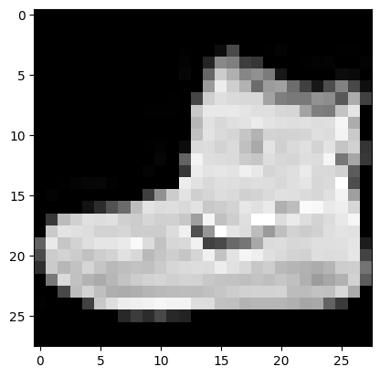

```python
# The most basic way: matplotlib's imshow on a single 2-D array.
b = next(iter(dl))      # dl here yields dict batches; grab one
xb = b['image']         # [16, 1, 28, 28]
img = xb[0]             # [1, 28, 28]  (channels-first)
plt.imshow(img[0]);     # img[0] -> [28,28]; ';' hides the returned object text
```

**What does the code above do?**

The raw approach, to motivate the toolkit. We grab a batch, take the first image `xb[0]` of shape `[1, 28, 28]`, and call `plt.imshow`. But `imshow` wants a 2-D `[H, W]` array for grayscale, while our tensor is `[C, H, W]` - so we must manually index `img[0]` to drop the channel axis. The trailing `;` suppresses Jupyter printing the returned object.

This is the friction we're about to remove: **PyTorch uses `[C, H, W]` (channels-first); matplotlib expects `[H, W, C]` (channels-last).** Every time you plot a tensor you'd otherwise hand-juggle that. `show_image` does it for you.

# Deep Dive: `show_image` - One Function for Every Image Type

## The Problem `show_image` Solves

In practice the thing you want to plot might be:

- a **PyTorch tensor** in `[C, H, W]` order, possibly on the GPU, possibly still attached to the autograd graph;
- a **PIL image**;
- a **NumPy array**;
- single-channel (grayscale) or three-channel (RGB).

`plt.imshow` handles none of that gracefully. `show_image` normalizes all of it into the `[H, W]` or `[H, W, C]` NumPy array matplotlib wants, then plots it.

## The Complete Code

```
#|export
@fc.delegates(plt.Axes.imshow)
def show_image(im, ax=None, figsize=None, title=None, noframe=True, **kwargs):
    if fc.hasattrs(im, ('cpu','permute','detach')):
        im = im.detach().cpu()
        if len(im.shape)==3 and im.shape[0]<5: im = im.permute(1,2,0)
    elif not isinstance(im, np.ndarray): im = np.array(im)
    if im.shape[-1]==1: im = im[...,0]
    if ax is None: _,ax = plt.subplots(figsize=figsize)
    ax.imshow(im, **kwargs)
    if title is not None: ax.set_title(title)
    ax.set_xticks([]); ax.set_yticks([])
    if noframe: ax.axis('off')
    return ax
```

## Line-by-Line

### `@fc.delegates(plt.Axes.imshow)`

This decorator (deep-dived in the next section) makes `show_image` quietly accept **all** of `imshow`'s keyword arguments - `cmap`, `vmin`, `vmax`, `alpha`, `interpolation`, ... - without us listing them. They flow through `**kwargs` to `ax.imshow`. So `show_image(img, cmap='hot')` just works.

### Detecting a tensor by behavior, not type

```
if fc.hasattrs(im, ('cpu','permute','detach')):
```

**What it does:** `fc.hasattrs` checks whether `im` has *all three* methods `cpu`, `permute`, `detach`. Only PyTorch tensors do. This is **duck typing** again - we ask "can it do tensor things?" rather than `isinstance(im, torch.Tensor)`.

**Why this design:** It's robust to tensor-like objects (subclasses, wrappers) and reads as intent: "if this behaves like a tensor, handle it the tensor way."

### Making a tensor matplotlib-safe

```
im = im.detach().cpu()
        if len(im.shape)==3 and im.shape[0]<5: im = im.permute(1,2,0)
```

**What it does:** Three fixes in order:

- `.detach()` - drop the autograd history. Matplotlib doesn't want a tensor that's still tracking gradients.
- `.cpu()` - move it off the GPU. Matplotlib can only read CPU memory.
- `.permute(1,2,0)` - reorder `[C, H, W] → [H, W, C]`, but **only** if it's a 3-D tensor whose first axis is small (`< 5`). That `< 5` is a clever heuristic: a real channel count is 1 (grayscale), 3 (RGB), or 4 (RGBA), all `< 5`, whereas a `[H, W]` image or a `28`-row anything wouldn't trip it. It distinguishes "channels-first image" from "already a 2-D image."

**Why this design:** These are the exact three reasons a raw tensor fails to plot. Doing them here, once, means you never think about them again.

### Handling PIL / other types

```
elif not isinstance(im, np.ndarray): im = np.array(im)
```

**What it does:** If `im` isn't a tensor and isn't already a NumPy array (so: a PIL image, or something array-like), convert it to a NumPy array. `np.array(pil_image)` produces an `[H, W]` or `[H, W, C]` array - already in matplotlib's preferred order.

### Squeezing a singleton channel

```
if im.shape[-1]==1: im = im[...,0]
```

**What it does:** If the last axis is length 1 (a `[H, W, 1]` grayscale), drop it to get `[H, W]`, which is what `imshow` expects for a single-channel image. `im[...,0]` means "keep all earlier axes, take index 0 of the last."

### Axes, drawing, and cleanup

```
if ax is None: _,ax = plt.subplots(figsize=figsize)
    ax.imshow(im, **kwargs)
    if title is not None: ax.set_title(title)
    ax.set_xticks([]); ax.set_yticks([])
    if noframe: ax.axis('off')
    return ax
```

**What it does:** If no axes was passed, make a fresh figure (so `show_image(img)` works standalone). Draw the image, forwarding any extra kwargs to `imshow`. Optionally set a title. Strip the tick marks and (by default) the whole frame, because axis numbers are meaningless on a picture. Finally **return the axes** - critical, because it lets *callers* place an image into a specific slot of a grid (which `show_images` relies on).

**Why return `ax`?** Returning the axes is what makes the function composable: `show_images` creates a grid of axes and calls `show_image(im, ax=that_slot)` for each one. Without the `ax` parameter and return, you couldn't direct images into a layout.

```python
#|export
@fc.delegates(plt.Axes.imshow)
def show_image(im, ax=None, figsize=None, title=None, noframe=True, **kwargs):
    "Show a PIL or PyTorch image on `ax`."
    if fc.hasattrs(im, ('cpu','permute','detach')):
        im = im.detach().cpu()                              # off the graph, onto CPU
        if len(im.shape)==3 and im.shape[0]<5:              # looks channels-first?
            im = im.permute(1,2,0)                          # [C,H,W] -> [H,W,C]
    elif not isinstance(im, np.ndarray):
        im = np.array(im)                                   # PIL/other -> numpy
    if im.shape[-1]==1: im = im[...,0]                      # [H,W,1] -> [H,W]
    if ax is None: _,ax = plt.subplots(figsize=figsize)     # make a figure if needed
    ax.imshow(im, **kwargs)
    if title is not None: ax.set_title(title)
    ax.set_xticks([]); ax.set_yticks([])                    # no tick marks on a picture
    if noframe: ax.axis('off')
    return ax                                               # return ax so callers can compose
```

**What does the code above do?**

The exported `show_image`, exactly as dissected above: it accepts a tensor / PIL / NumPy image, normalizes it to what matplotlib wants (CPU, channels-last, squeezed grayscale), draws it, tidies the axes, and returns the `ax` so it can be slotted into a grid. The `#|export` ships it to `miniai.datasets`.

```python
# @fc.delegates means show_image inherited ALL of imshow's params - see the docstring.
help(show_image)
```

```
Help on function show_image in module __main__:

show_image(im, ax=None, figsize=None, title=None, noframe=True, *, cmap=None, norm=None, aspect=None, interpolation=None, alpha=None, vmin=None, vmax=None, colorizer=None, origin=None, extent=None, interpolation_stage=None, filternorm=True, filterrad=4.0, resample=None, url=None, data=None)
    Show a PIL or PyTorch image on `ax`.
```

**What does the code above do?**

`help(show_image)` prints the signature and docstring. The striking part: it lists **many parameters we never wrote** - `cmap`, `norm`, `aspect`, `interpolation`, `alpha`, `vmin`, `vmax`, `origin`, ... Those were injected by `@fc.delegates(plt.Axes.imshow)`, which copied `imshow`'s signature onto ours. That's the subject of the next deep-dive.

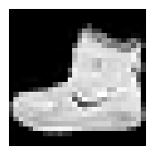

```python
# show_image handles the tensor automatically - no manual permute/cpu needed.
show_image(img, figsize=(2,2));
```

**What does the code above do?**

One call, and the `[1, 28, 28]` tensor `img` is displayed in a compact 2×2-inch figure. Behind the scenes `show_image` moved it to CPU, permuted to `[28, 28, 1]`, squeezed to `[28, 28]`, and plotted it - all the friction from the raw-`imshow` cell, gone.

[figure not shown]

```python
# Two images side by side: pass each a specific axes from plt.subplots.
fig, axs = plt.subplots(1, 2)    # 1 row, 2 columns -> axs is an array of 2 axes
show_image(img, axs[0])           # left slot
show_image(xb[1], axs[1]);        # right slot
```

**What does the code above do?**

To show several images we need several **axes**. `plt.subplots(1, 2)` makes a figure with a 1×2 grid and returns `axs`, an array of two axes. We then call `show_image(im, ax)` once per slot, directing the first image to `axs[0]` and the second to `axs[1]`. This is exactly why `show_image` takes an `ax` argument and returns it - composition into layouts. Manually computing `figsize` for bigger grids gets old fast, which motivates `subplots`.

# Deep Dive: `fc.delegates` - Borrowing Another Function's Parameters

## The Problem `delegates` Solves

`show_image` ends in `**kwargs` and forwards them to `ax.imshow`. That works at *runtime* - you can pass `cmap='hot'` and it'll reach `imshow`. But it's invisible to *humans and tools*: `help(show_image)` would just show `**kwargs`, with no hint of which options are available. You'd have to go read matplotlib's docs.

`fc.delegates` fixes the **discoverability** gap. It's a fastcore decorator that copies the parameter list (and docs) from the function you delegate to, replacing the bare `**kwargs` in your signature with the real, named parameters of the target.

## What It Does, Concretely

```
@fc.delegates(plt.Axes.imshow)
def show_image(im, ax=None, ..., **kwargs): ...
```

After this, `show_image`'s signature **advertises** `imshow`'s keyword arguments (`cmap`, `vmin`, `vmax`, `alpha`, ...). They show up in `help()`, in IDE autocomplete, and in nbdev-generated docs. At runtime they still flow through `**kwargs` to `imshow` exactly as before - `delegates` changes the *advertised* signature, not the behavior.

## Why This Matters

It's the difference between a function that's *technically* flexible and one that's *usably* flexible. With `delegates`, a newcomer typing `show_image(img,` and hitting Tab sees `cmap=`, `alpha=`, and friends offered to them. Without it, those options exist but are hidden behind `**kwargs`. fast.ai uses `delegates` pervasively for exactly this reason - it keeps wrapper functions thin *and* self-documenting.

The optional `keep=True` argument (used in `subplots` below) tells `delegates` to **also keep your own explicit parameters** in the signature, rather than letting the delegated ones replace them. You want that whenever your wrapper adds parameters of its own (like `imsize`) that you don't want to lose.

```python
#|export
@fc.delegates(plt.subplots, keep=True)
def subplots(
    nrows:int=1,         # rows in the grid
    ncols:int=1,         # cols in the grid
    figsize:tuple=None,  # (w,h) inches; auto-computed if None
    imsize:int=3,        # inches per image, used to auto-size the figure
    suptitle:str=None,   # optional figure-level title
    **kwargs
):
    "A figure and set of subplots to display images of `imsize` inches."
    if figsize is None: figsize = (ncols*imsize, nrows*imsize)   # auto-size
    fig,ax = plt.subplots(nrows, ncols, figsize=figsize, **kwargs)
    if suptitle is not None: fig.suptitle(suptitle)
    if nrows*ncols==1: ax = np.array([ax])   # always return an array, even for 1x1
    return fig,ax
```

**What does the code above do?**

`subplots` is a friendlier `plt.subplots`. Three conveniences:

1. **Auto-sizing.** If you don't pass `figsize`, it computes one from `imsize`: `(ncols*imsize, nrows*imsize)`. So a 3×3 grid at `imsize=2` becomes a `(6, 6)`-inch figure automatically - you think in "inches per image," not total figure size.
2. **`suptitle`.** A one-arg way to put a title across the whole figure.
3. **Always an array.** Plain `plt.subplots(1,1)` returns a *single* axes object, but `plt.subplots(2,2)` returns an *array* - so code that iterates over axes breaks for the 1×1 case. The line `if nrows*ncols==1: ax = np.array([ax])` wraps the lone axes in an array, so `ax.flat` works uniformly no matter the grid size.

`@fc.delegates(plt.subplots, keep=True)` borrows `plt.subplots`'s own params (`sharex`, `sharey`, ...) into the signature, and `keep=True` keeps our `nrows/ncols/imsize/...` too.

```python
from nbdev.showdoc import show_doc   # nbdev's formatted documentation renderer
```

**What does the code above do?**

Imports `show_doc` from nbdev, a helper that renders a function's signature and docstring as a nicely formatted table (used when building documentation sites from notebooks). It's purely for display.

```python
show_doc(subplots)   # note: delegates copied plt.subplots' params into the signature
```

subplots

```
def subplots(
    nrows:int=1, # rows in the grid
    ncols:int=1, # cols in the grid
    figsize:tuple=None, # (w,h) inches; auto-computed if None
    imsize:int=3, # inches per image, used to auto-size the figure
    suptitle:str=None, # optional figure-level title
    sharex:bool | Literal['none', 'all', 'row', 'col']=False,
    sharey:bool | Literal['none', 'all', 'row', 'col']=False, squeeze:bool=True,
    width_ratios:Sequence[float] | None=None, height_ratios:Sequence[float] | None=None,
    subplot_kw:dict[str, Any] | None=None, gridspec_kw:dict[str, Any] | None=None, kwargs:VAR_KEYWORD
):
```

*A figure and set of subplots to display images of `imsize` inches.*

**What does the code above do?**

`show_doc(subplots)` displays the formatted documentation. You can see `@fc.delegates(..., keep=True)` at work: the signature shows both *our* parameters (`nrows`, `ncols`, `imsize`, `suptitle`) **and** the delegated ones inherited from `plt.subplots`. Self-documenting, as promised.

[figure not shown]

```python
# Use subplots to lay out 8 images in a 3x3 grid (9 slots; last one stays empty).
fig, axs = subplots(3, 3, imsize=1)
imgs = xb[:8]
for ax, img in zip(axs.flat, imgs):   # axs.flat flattens the 2-D axes array to 1-D
    show_image(img, ax)
```

**What does the code above do?**

`subplots(3, 3, imsize=1)` builds a 3×3 grid of 1-inch slots (auto figsize `(3, 3)`). `axs.flat` flattens the 2-D array of 9 axes into a 1-D sequence so we can iterate it easily. `zip(axs.flat, imgs)` pairs each axes with an image, and we `show_image` each into its slot. We have 8 images but 9 slots, so the last slot is left blank - which motivates `get_grid`, which sizes the grid to the data *and* hides leftover slots.

## `get_grid`: auto-sizing the grid to `n` images

Counting rows and columns by hand is tedious and easy to get wrong (as the empty 9th slot just showed). `get_grid(n)` computes a sensible near-square grid for `n` items and switches off any leftover slots.

### 🎮 Interactive: get_grid - auto-arranging images into a tidy grid

Drag the slider for **n** images and watch `nrows × ncols` recompute (default: a near-square `floor(√n)` rows), with any trailing empty slots switched off. Flip to the *fix rows* / *fix cols* modes to see the other two branches of the logic - including the gotcha where forcing too few rows leaves slots `<` n.

```python
from IPython.display import IFrame
IFrame("https://shammun.github.io/shammunul-fastai-notes/notebooks/interactive_viz/get_grid_autolayout.html", width="100%", height=540)
```

[interactive chart not shown]

```python
#|export
# ^ nbdev "export" directive. Marks this cell to be written out into the
#   miniai.datasets module (miniai/datasets.py) when the notebook is compiled,
#   so get_grid becomes importable elsewhere with `from miniai.datasets import *`.

@fc.delegates(subplots)
# ^ fastcore's @delegates decorator. `subplots` accepts many keyword args
#   (figsize, sharex, sharey, etc.). Instead of re-listing them all here,
#   @delegates replaces the bare **kwargs in get_grid's signature with the
#   *actual* keyword params of `subplots`. Result: tab-completion, proper
#   docs, and type hints show subplots' real options, not an opaque **kwargs.
def get_grid(
    n:int,              # number of axes (subplots) we ultimately need to draw
    nrows:int=None,     # how many rows to use; if left None we'll compute it
    ncols:int=None,     # how many cols to use; if left None we'll compute it
    title:str=None,     # optional overall figure title (suptitle); None = no title
    weight:str='bold',  # font weight for that title
    size:int=14,        # font size for that title
    **kwargs,           # any extra keyword args get forwarded straight to subplots
                        #   (e.g. figsize, sharex). @delegates documents these.
):
    "Return a grid of `n` axes, `rows` by `cols`."
    # ^ One-line docstring. fastcore/nbdev surface this as the function's summary.

    # --- Figure out the grid shape (nrows x ncols) ---------------------------
    if nrows:
        # Caller gave us a row count. Derive the column count from it.
        # `ncols or ...` means: keep ncols if the caller also passed it,
        # otherwise compute cols = floor(n / nrows).
        ncols = ncols or int(np.floor(n/nrows))   # rows given -> derive cols
    elif ncols:
        # Caller gave us only a column count. Derive the row count instead.
        # We use ceil here so every one of the n axes is guaranteed a slot
        # (ceil rounds up, so rows*cols >= n).
        nrows = nrows or int(np.ceil(n/ncols))    # cols given -> derive rows
    else:
        # Caller gave neither -> build a near-square grid automatically.
        nrows = int(math.sqrt(n))                 # rows ~= sqrt(n) (side of a square)
        ncols = int(np.floor(n/nrows))            # cols = floor(n / rows)

    # --- Create the actual matplotlib figure and axes ------------------------
    fig,axs = subplots(nrows, ncols, **kwargs)
    # ^ Build the figure with the computed shape, passing through any extra
    #   kwargs (figsize, etc.). `axs` is the array of Axes objects.

    # --- Hide any leftover empty cells ---------------------------------------
    # Because nrows*ncols can exceed n (the grid may have more slots than
    # images), loop over the surplus slots and switch their axes off so we
    # don't show empty boxes with ticks. axs.flat flattens the 2-D axes grid
    # into a 1-D iterable; indices n .. nrows*ncols-1 are the extra slots.
    for i in range(n, nrows*ncols): axs.flat[i].set_axis_off()  # hide extra slots

    # --- Optional figure-level title -----------------------------------------
    if title is not None:
        fig.suptitle(title, weight=weight, size=size)  # add a bold title above all axes

    # --- Hand back the figure and axes so the caller can draw into them ------
    return fig,axs
```

**What does the code above do?**

`get_grid(n)` picks grid dimensions and returns the figure + axes. The dimension logic has three branches:

| You pass | It computes | Example (n=8) |
| --- | --- | --- |
| `nrows` only | `ncols = floor(n/nrows)` | `nrows=3 → ncols=floor(8/3)=2` |
| `ncols` only | `nrows = ceil(n/ncols)` | `ncols=4 → nrows=ceil(8/4)=2` |
| neither | `nrows = floor(√n)`, `ncols = floor(n/nrows)` | `nrows=2, ncols=4` |

The default (neither given) aims for a **near-square** grid - pleasant to look at. After building the grid, the loop `for i in range(n, nrows*ncols): axs.flat[i].set_axis_off()` **switches off every slot beyond the `n`-th**, so leftover cells don't show as ugly empty axes with ticks.

One honest caveat (the interactive shows it): if you *force* `nrows` such that `nrows × ncols < n` - e.g. `nrows=3` for `n=8` gives only `3×2=6` slots - then two images won't fit. When overriding, make sure the slots cover `n`.

[figure not shown]

```python
# Force 3 rows for 8 images: floor(8/3)=2 cols -> only 6 slots (2 imgs won't fit).
# ^ This is a deliberate "gotcha" demo. We ask for 8 images but pin nrows=3.
#   Inside get_grid, the `if nrows:` branch derives ncols = floor(n/nrows)
#   = floor(8/3) = 2. So the grid is 3 rows x 2 cols = 6 slots only.
#   Because floor rounds DOWN, 6 < 8, meaning 2 of the 8 images have no cell
#   and simply won't be drawn. (Contrast: deriving rows from cols uses ceil,
#   which rounds UP and would guarantee enough slots. Deriving cols from rows
#   uses floor, which can come up short, as here.)

fig, axs = get_grid(8, nrows=3, imsize=1)
# ^ Build the grid: n=8 axes requested, forced to 3 rows.
#   - nrows=3 is passed explicitly, so ncols is computed as floor(8/3)=2.
#   - imsize=1 is an extra kwarg forwarded through **kwargs to subplots
#     (it controls the size, in inches, of each individual subplot).
#   Returns the Figure (fig) and the array of Axes (axs), here a 3x2 grid.

for ax, img in zip(axs.flat, imgs):
    # ^ Pair up each axis with each image so we can draw one image per cell.
    #   - axs.flat flattens the 3x2 Axes grid into a 1-D sequence of 6 axes.
    #   - imgs is the collection of 8 images we want to display.
    #   - zip() stops at the SHORTER of the two: 6 axes vs 8 images -> 6 pairs.
    #     That's exactly why only the first 6 images get shown and the last
    #     2 are silently dropped (no error, they just never get an axis).
    show_image(img, ax)
    # ^ Draw this image into its paired axis. show_image is the miniai helper
    #   that renders a tensor/array image onto the given matplotlib Axes.
```

**What does the code above do?**

A live demonstration of that very caveat. We ask for `nrows=3` with `n=8`. `get_grid` computes `ncols = floor(8/3) = 2`, giving a `3×2 = 6`-slot grid - **fewer slots than images**. `zip` stops at the shorter sequence (6 slots), so only 6 of the 8 images display. The lesson: when you override grid dimensions, pick values whose product is `≥ n` (here, `ncols=3` would give 9 slots). When in doubt, let `get_grid` choose for you.

```python
#|export
# ^ nbdev "export" directive. Marks this cell to be written into miniai/datasets.py
#   when the notebook is compiled, so show_images is importable via
#   `from miniai.datasets import *`.

# ---------------------------------------------------------------------------
# A NOTE ON THE `int|None` TYPE HINTS USED BELOW
# ---------------------------------------------------------------------------
# Several arguments are written like `nrows:int|None=None`. Reading that:
#   nrows      -> the parameter name
#   :int|None  -> the TYPE HINT. The `|` means "OR", so this reads
#                 "an int OR None". This is called a UNION TYPE.
#   =None      -> the DEFAULT value if the caller doesn't pass one.
#
# So `nrows:int|None=None` means: "nrows may be an int or None, default None."
#
# Key facts about this syntax:
#   - `|` for types was added in Python 3.10 (PEP 604). It's the modern,
#     cleaner form of the older `Optional[int]` or `Union[int, None]` from
#     the `typing` module. `int|None` == `Optional[int]` == `Union[int,None]`.
#   - Type hints are NOT enforced at runtime. Python won't stop you from
#     passing the "wrong" type; they're documentation for humans and for
#     tools (IDE autocomplete, type checkers like mypy).
#   - We use `int|None` here exactly because each of these args defaults to
#     None and only takes a real value when the caller supplies one. The hint
#     signals: "pass an int (or a list), OR leave it None for auto behaviour."
# ---------------------------------------------------------------------------

@fc.delegates(subplots)
# ^ fastcore's @delegates. Replaces the bare **kwargs below with the real
#   keyword parameters of `subplots` (figsize, imsize, sharex, ...), so docs
#   and tab-completion show subplots' actual options instead of an opaque
#   **kwargs. Those kwargs ultimately flow through get_grid into subplots.
def show_images(ims:list,                  # the list of images we want to display
                nrows:int|None=None,       # rows: an int, OR None to let get_grid decide
                ncols:int|None=None,       # cols: an int, OR None to let get_grid decide
                titles:list|None=None,     # titles: a list of per-image titles, OR None for none
                **kwargs):                 # extra args forwarded down to get_grid/subplots
                                           #   (e.g. imsize, figsize). Documented by @delegates.
    "Show all images `ims` as subplots with `rows` using `titles`."
    # ^ One-line docstring summarising the function for nbdev/fastcore.

    # --- Build the grid and grab a flat list of axes -------------------------
    axs = get_grid(len(ims), nrows, ncols, **kwargs)[1].flat
    # ^ Step by step:
    #   - len(ims) tells get_grid how many axes we need (one per image).
    #   - nrows/ncols/**kwargs are passed straight through; get_grid figures
    #     out the grid shape and forwards kwargs (imsize, etc.) to subplots.
    #   - get_grid returns a (fig, axs) tuple; [1] picks out just `axs`
    #     (the array of Axes), discarding the figure we don't need here.
    #   - .flat flattens the 2-D Axes grid into a 1-D iterator so we can walk
    #     it one axis at a time alongside the images.

    # --- Draw each image (with its optional title) into one axis -------------
    for im,t,ax in zip_longest(ims, titles or [], axs):
        # ^ zip_longest (NOT plain zip) pairs images, titles, and axes together,
        #   continuing until the LONGEST iterable is exhausted, filling missing
        #   values with None. Why zip_longest here?
        #   - `titles or []` substitutes an empty list when titles is None, so
        #     the zip still works; every image then gets t=None (no title).
        #   - Even if there are fewer titles than images, the extra images still
        #     get drawn with t=None instead of being dropped (plain zip would
        #     stop at the shortest and silently skip images).
        show_image(im, ax=ax, title=t)
        # ^ Render image `im` into axis `ax`, with title `t` (or no title if
        #   t is None). show_image is the miniai helper that draws a
        #   tensor/array image onto the given matplotlib Axes.
```

**What does the code above do?**

`show_images` is the **one-liner** that ties the toolkit together. Given a list of images (and optionally titles), it:

1. `get_grid(len(ims), ...)` - build a grid sized to the number of images; `[1]` takes the axes (it returns `(fig, axs)`), `.flat` flattens them to 1-D.
2. `zip_longest(ims, titles or [], axs)` - pair each image with its title and its axes slot. The key choice here is **`zip_longest`** (not `zip`): if you pass fewer titles than images (or no titles at all - `titles or []` makes it an empty list), `zip_longest` pads the missing titles with `None` instead of stopping early. So `show_image(im, ax=ax, title=None)` simply draws the image with no title. Plain `zip` would have silently dropped images whenever titles ran short.
3. `show_image(im, ax=ax, title=t)` - draw each image into its slot with its (optional) title.

The result: `show_images(my_imgs, titles=my_labels)` displays a labeled grid in one call.

```python
# Prepare 8 labels to use as titles.
yb = b['label']     # labels from the dict batch
lbls = yb[:8]
lbls
```

```
tensor([9, 0, 0, 3, 0, 2, 7, 2])
```

**What does the code above do?**

Grab the label tensor from the batch and take the first 8 (`lbls`), to match the 8 images we'll display. These are integer class indices; next we turn them into readable names.

```python
# Map label indices -> short class names, using itemgetter again.
names = "Top Trouser Pullover Dress Coat Sandal Shirt Sneaker Bag Boot".split()
titles = itemgetter(*lbls)(names)   # (names[9], names[0], ...) in label order
' '.join(titles)
```

```
'Boot Top Top Dress Top Pullover Sneaker Pullover'
```

**What does the code above do?**

`names` is a list of 10 short class names (`names[0]='Top'`, ..., `names[9]='Boot'`), built by `.split()`-ing a space-separated string. Then the clever line: `itemgetter(*lbls)(names)`. We *unpack the labels themselves* as the keys - so for `lbls = [9, 0, 0, 3, ...]` this is `itemgetter(9, 0, 0, 3, ...)(names)`, which returns `(names[9], names[0], names[0], names[3], ...) = ('Boot', 'Top', 'Top', 'Dress', ...)`. Here `itemgetter` is indexing a **list** by integer positions, not a dict by string keys - the same tool, duck-typed onto a different container. `' '.join(titles)` prints them as a quick sanity string.

[figure not shown]

```python
# The payoff: 8 labeled images in a single line.
show_images(imgs, imsize=1.7, titles=titles)
```

**What does the code above do?**

The whole toolkit in one call. `show_images(imgs, imsize=1.7, titles=titles)` auto-builds a 2×4 grid (via `get_grid(8)`), sizes it, and draws each Fashion-MNIST image with its class name as a title. *This* is the function you'll reach for constantly: to inspect a batch of training data, to compare predictions against truth, to visualize augmentations. One line, and you can *see* your data.

# Part 7: The `DataLoaders` Wrapper

Training needs **two** loaders: one for the training split (shuffled) and one for validation (not shuffled). Passing them around as two separate variables is clumsy. `DataLoaders` bundles them into one object with `.train` and `.valid` attributes, plus a factory `from_dd` that builds both straight from a Hugging Face `DatasetDict`.

```python
#|export
class DataLoaders:
    def __init__(self, *dls): self.train,self.valid = dls[:2]   # first two -> train, valid

    @classmethod
    def from_dd(cls, dd, batch_size, as_tuple=True, **kwargs):
        f = collate_dict(dd['train'])                           # tuple-collate from features
        return cls(*get_dls(*dd.values(), bs=batch_size, collate_fn=f, **kwargs))
```

**What does the code above do?**

A small but heavily-used class.

**`__init__(self, *dls)`** accepts any number of DataLoaders and stores the first two as `self.train` and `self.valid`. The `*dls` lets you call `DataLoaders(train_dl, valid_dl)` and have them captured as a tuple.

**`from_dd` (a `@classmethod`, i.e. a factory)** builds everything from a `DatasetDict`:

- `f = collate_dict(dd['train'])` - construct the tuple-returning collate function from the training split's features (reusing our deep-dived factory).
- `get_dls(*dd.values(), bs=batch_size, collate_fn=f, **kwargs)` - `dd.values()` is `[train_ds, test_ds]`; `*` unpacks them as the two positional datasets to `get_dls` (our notebook-04 helper that wraps each in a `DataLoader`, shuffling train but not valid). The `*` in front of `get_dls(...)` then unpacks the *returned* pair of loaders straight into `cls(...)`.

So one call - `DataLoaders.from_dd(dsd, batch_size=128)` - turns a raw `DatasetDict` into a tidy object exposing `dls.train` and `dls.valid`, each yielding `(xb, yb)` tuples. This is the object every subsequent notebook's training loop receives.

**Usage:**

```
dsd = load_dataset('fashion_mnist').with_transform(transformi)
dls = DataLoaders.from_dd(dsd, batch_size=128)
for xb, yb in dls.train: ...   # train
for xb, yb in dls.valid: ...   # validate
```

## Deep Dive: `DataLoaders.from_dd` - every symbol explained, with Fashion-MNIST data

The class above is only five lines, but it leans on **three** different Python features at once - `*args`, `@classmethod`, and `**kwargs` - and it reuses the `*` symbol for two *opposite* jobs. That trips up almost everyone the first time. So let's slow all the way down and name **every** piece, using the exact data we already built in this notebook: the Fashion-MNIST `DatasetDict` (`dsd`) and the `transformi` transform.

### One-line mental model

> `DataLoaders.from_dd(dsd, batch_size=128)` takes the **two raw splits** inside a Hugging Face `DatasetDict` and hands you back **one object** whose `.train` and `.valid` attributes are ready-to-use PyTorch `DataLoader`s, each already yielding `(xb, yb)` tuples.

Everything below is just *how* that one line works.

### The cast of characters

| Symbol | Plain-English meaning | Concrete value when we call `from_dd(dsd, batch_size=128)` |
| --- | --- | --- |
| `cls` | The **class itself**, passed in automatically because `from_dd` is a `@classmethod`. Here it *is* `DataLoaders`. | `DataLoaders` |
| `dd` | A **D**ataset**D**ict - the dict-like object `load_dataset(...)` returns, mapping a split-name to a `Dataset`. | `dsd`, i.e. `{'train': Dataset(60000), 'test': Dataset(10000)}` |
| `batch_size` | How many samples go in each **training** batch. (Validation uses `batch_size*2` - see `get_dls` below.) | `128` |
| `as_tuple` | A keyword that is **accepted but not actually used** in this version of the body - a placeholder kept for API compatibility. Setting it to `False` changes nothing here. | `True` (the default) |
| `**kwargs` | "Catch any *other* keyword arguments and forward them on." Lets options like `num_workers=4` tunnel through to PyTorch's `DataLoader`. | `{}` (we passed none) |
| `*dls` (in `__init__`) | "Collect *all* positional arguments into a tuple called `dls`." | `(train_dl, valid_dl)` |
| `f` | The tuple-returning collate function that `collate_dict` builds from the training split's features (`'image'`, `'label'`). | a function `b -> (xb, yb)` |

### `cls` - the part everyone asks about

In a **regular** method the first parameter is `self` - one particular *instance* of the class. In a **`@classmethod`** the first parameter is `cls` - the *class itself*. You never pass it by hand: when you write `DataLoaders.from_dd(dsd, batch_size=128)`, Python silently slips the `DataLoaders` class in as `cls`.

So inside the method these are all true:

```
cls is DataLoaders          # True
cls(train_dl, valid_dl)     # identical to  DataLoaders(train_dl, valid_dl)
```

**Why write `cls(...)` instead of just `DataLoaders(...)`?** Because `cls` means "whatever class this method was actually called on," it keeps the factory **inheritance-friendly**:

```
class GPUDataLoaders(DataLoaders): ...
dls = GPUDataLoaders.from_dd(dsd, 128)   # cls is GPUDataLoaders -> you get a GPUDataLoaders back
```

Hard-coding `DataLoaders(...)` would always build the base class, even when the method is called on a subclass. `cls` does the right thing for free. This is the whole reason `from_dd` is a `@classmethod` and not a plain function: a factory's job is to *construct the class it lives on*.

### A gentle, example-first tour of `@classmethod`

Forget data loaders for a minute. Let's build the idea from the *smallest* possible story and only come back to our real code at the very end.

**Step 1 - a normal class with a normal method.**

```
class Dog:
    def __init__(self, name, age):
        self.name = name
        self.age  = age

    def bark(self):                 # a NORMAL method - its first arg is `self`
        print(self.name, "says woof!")

rex = Dog("Rex", 3)                 # build a Dog the normal way -> runs __init__
rex.bark()                          # Rex says woof!
```

Two things to notice:

- `Dog("Rex", 3)` is the **normal way to build a Dog**: it runs `__init__`.
- `bark(self)` receives `self` = *that one particular dog* (`rex`). You call it **on an instance**: `rex.bark()`.

**Step 2 - the problem.** Suppose your data arrives as a **string** `"Rex,3"` (say, a line from a CSV), not as two tidy arguments. You *could* split it by hand every single time:

```
s = "Rex,3"
name, age = s.split(",")
rex = Dog(name, int(age))           # works - but you retype this everywhere
```

Annoying. Wouldn't it be nicer to just say `Dog.from_string("Rex,3")` and get a Dog back? That is *exactly* what a `@classmethod` gives you.

**Step 3 - add an "alternative constructor" with `@classmethod`.**

```
class Dog:
    def __init__(self, name, age):
        self.name = name
        self.age  = age

    @classmethod
    def from_string(cls, s):        # first arg is `cls`, NOT `self`
        name, age = s.split(",")
        return cls(name, int(age))  # cls is `Dog`, so this line is Dog(name, int(age))

rex = Dog.from_string("Rex,3")      # <-- call it ON THE CLASS; no dog exists yet!
print(rex.name, rex.age)            # Rex 3
```

Walk through *exactly* what happens in `Dog.from_string("Rex,3")`:

1. You call it **on the class** `Dog` (not on a dog object - there isn't one yet).
2. Because it is a `@classmethod`, Python **automatically** passes the class in as the first argument, so `cls = Dog`. You only typed `"Rex,3"`, which became `s`.
3. Inside, `cls(name, int(age))` is literally `Dog("Rex", 3)` - so it runs the normal `__init__` and builds a real Dog.
4. That fresh Dog is `return`ed, so `rex` is a perfectly ordinary `Dog`.

The single most important fact:

```
# inside a @classmethod, `cls` IS the class itself:
cls is Dog          # True
cls("Rex", 3)       # the exact same thing as  Dog("Rex", 3)
```

So `cls` is **not** a mysterious object. It is just the word `Dog`, written in a way that *also* keeps working for subclasses.

**Step 4 - the "two doors" picture.** A class can have more than one way in:

```
Dog("Rex", 3)              # FRONT DOOR (__init__): you already hold clean ingredients
Dog.from_string("Rex,3")   # SIDE DOOR (@classmethod): you hold raw material; it preps it,
                           #   then walks through the front door for you via cls(...)
```

`from_string` does **not** replace `__init__`. It does a little **prep** (`split`, `int`) and then **hands the finished ingredients to `__init__`** through `cls(...)`. The `@classmethod` is the side door; `cls(...)` is that side door opening the front door from the inside.

**Step 5 - a second tiny example, to show the shape never changes.**

```
class Temperature:
    def __init__(self, celsius):
        self.celsius = celsius

    @classmethod
    def from_fahrenheit(cls, f):
        return cls((f - 32) * 5/9)  # convert raw -> then build via the normal constructor

t = Temperature.from_fahrenheit(212)   # boiling water, in Fahrenheit
print(t.celsius)                       # 100.0
```

Notice it is the *same shape* as the Dog: **`from_X(cls, raw)` -> convert `raw` -> `return cls(clean)`**. Any time you meet a constructor named `from_something`, this is almost certainly what is going on under the hood.

**Step 6 - now re-read our REAL code with these eyes.** `DataLoaders` is *exactly* the `Dog` story, just with bigger ingredients:

```
class DataLoaders:
    def __init__(self, *dls):                  # FRONT DOOR: hand me finished loaders
        self.train, self.valid = dls[:2]

    @classmethod
    def from_dd(cls, dd, batch_size, ...):      # SIDE DOOR: hand me a raw DatasetDict
        f = collate_dict(dd['train'])           #   ...do some prep...
        return cls(*get_dls(*dd.values(), bs=batch_size, collate_fn=f, ...))  # ...then front door
```

The mapping, row by row:

| In the `Dog` example | In `DataLoaders` | Its role |
| --- | --- | --- |
| `Dog("Rex", 3)` | `DataLoaders(train_dl, valid_dl)` | **front door** (`__init__`) - needs finished pieces |
| `Dog.from_string("Rex,3")` | `DataLoaders.from_dd(dsd, 128)` | **side door** (`@classmethod`) - takes raw material |
| `s = "Rex,3"` (raw input) | `dd = dsd` (raw `DatasetDict`) | the raw material handed in |
| `name, age = s.split(",")` (prep) | `f = collate_dict(...)`, `get_dls(...)` (prep) | turn raw -> finished pieces |
| `return cls(name, int(age))` | `return cls(*get_dls(...))` | hand finished pieces to the front door |
| `cls is Dog` | `cls is DataLoaders` | `cls` is just the class's own name |

So when you finally read this intimidating line:

```
return cls(*get_dls(*dd.values(), bs=batch_size, collate_fn=f, **kwargs))
```

it is doing the **same job** as `return cls(name, int(age))` in `Dog.from_string`: it preps the ingredients (`get_dls(...)` builds the two loaders), then passes them to the front door `cls(...)` (= `DataLoaders(...)`), which stores them as `.train` and `.valid`. The only extra wrinkle is the `*`, which merely spreads the returned `(train_dl, valid_dl)` tuple into two separate arguments (see "The two faces of `*`" above).

> **The whole idea in one breath:** `@classmethod` gives `DataLoaders` a second, convenient constructor (`from_dd`) that you call straight on the class; Python feeds it the class as `cls`; it does the boring prep; and it finishes by calling the normal constructor via `cls(...)` - precisely the way `Dog.from_string("Rex,3")` builds a `Dog` from a messy string.

If the `Dog` example makes sense, you already fully understand `from_dd`. The next section is just the same idea stated more formally (what `@classmethod` does *mechanically*), for when you want the under-the-hood version.

### What `@classmethod` actually does

`@classmethod` is a built-in decorator that changes **one thing**: *which object Python automatically passes in as the method's first argument.*

| Kind of method | First arg you receive | How you call it | Needs an existing instance? |
| --- | --- | --- | --- |
| regular method | `self` - the **instance** | `instance.method()` | yes |
| `@classmethod` | `cls` - the **class** | `Class.method()` (or `instance.method()`) | **no** |
| `@staticmethod` | nothing special | `Class.method()` | no |

So `@classmethod` lets you call `DataLoaders.from_dd(dsd, 128)` **directly on the class**, before any `DataLoaders` object exists - which is exactly what you need for a method whose *whole job is to create one*.

**What it does to the code (mechanically).** The `@` line is pure syntactic sugar. These two definitions are identical:

```
class DataLoaders:
    @classmethod
    def from_dd(cls, dd, batch_size, ...): ...

# ...is exactly the same as:

class DataLoaders:
    def from_dd(cls, dd, batch_size, ...): ...
    from_dd = classmethod(from_dd)
```

`classmethod(...)` wraps the function in a **descriptor**. When you later access `DataLoaders.from_dd`, that descriptor hands back a *bound method* with the class already slotted into the first parameter. That is why you call `from_dd(dsd, 128)` with **two** arguments even though the header lists **three** (`cls, dd, batch_size`): Python fills in `cls` for you, automatically.

**Why we use it here - it is an "alternative constructor."** A class normally has one entry point, `__init__`, and it expects *already-built* pieces: `DataLoaders(train_dl, valid_dl)`. But often you start from *raw* material instead - here a `DatasetDict`. A `@classmethod` factory adds a second, friendlier door:

```
DataLoaders(train_dl, valid_dl)            # low-level: you already have the loaders
DataLoaders.from_dd(dsd, batch_size=128)   # high-level: start from raw data
```

`from_dd` does the prep work (build the collate fn `f`, call `get_dls`) and then funnels the result through the *normal* constructor via `cls(...)`. This is a standard Python idiom - the same pattern behind `dict.fromkeys(...)`, `datetime.fromtimestamp(...)`, and `torch.Tensor.from_numpy(...)`. A name like `from_X` is almost always a tell-tale sign of a `@classmethod` constructor.

**How it changes behavior vs. a plain function.** You *could* instead write a module-level `def make_dataloaders(dd, bs): return DataLoaders(...)`. It would even work. Making it a `@classmethod` buys two things:

1. **Grouping / discoverability** - it lives *on* the class (`DataLoaders.from_dd`), right where you would look for "how do I build one of these?"
2. **Inheritance** - because it receives `cls` (not a hard-coded `DataLoaders`), a subclass automatically gets a factory that builds *itself*, as shown in the `cls` section above.

> **Rule of thumb:** reach for `@classmethod` when a method needs the **class** but not any specific **instance** - most often to build and return an instance (a factory / alternative constructor). Reach for `@staticmethod` when it needs *neither* (just a helper parked in the class's namespace). Use a plain method when it works on a particular object's data via `self`.

### `dd` - the DatasetDict, concretely

`dd` is just short for **DatasetDict**. In this notebook it is exactly `dsd`. It behaves like an ordinary dictionary keyed by split name:

```
dd['train']     # -> the Dataset of 60,000 training images
dd['test']      # -> the Dataset of 10,000 test images
dd.values()     # -> [train_ds, test_ds]   (the splits, in order)
```

Two different accesses happen in the body, for two different reasons:

- `dd['train']` - grab **only the training split**, because `collate_dict` needs *a* dataset to read the feature names (`'image'`, `'label'`) from. Train and test share the same features, so either would do; train is the conventional choice.
- `dd.values()` - grab **both splits as a list**, to feed them as the two datasets that `get_dls` expects.

### The two faces of `*`

This is the crux, and the bit worth re-reading. The same `*` symbol does two **opposite** things in this class:

**1. `*` in a *definition* = "pack" (collect many arguments into one tuple).**

```
def __init__(self, *dls):          # dls becomes a tuple of however many args you passed
    self.train, self.valid = dls[:2]
```

Call `DataLoaders(a, b)` and inside the method `dls == (a, b)`. We then keep the first two as `.train` and `.valid`. (Why allow more than two? Some later code passes a separate test loader as a third argument - it is simply ignored here.)

**2. `*` in a *call* = "unpack / splat" (spread one iterable out into many arguments).**

```
get_dls(*dd.values(), ...)         # *[train_ds, test_ds]   ->  get_dls(train_ds, test_ds, ...)
cls(*get_dls(...))                 # *(train_dl, valid_dl)  ->  cls(train_dl, valid_dl)
```

`get_dls` *returns* a 2-tuple `(train_dl, valid_dl)`; the `*` in front splats that tuple into two positional arguments to `cls`, which `__init__` then re-packs into `dls`. Pack -> unpack -> pack again: that little round-trip is exactly what lets `from_dd` stay agnostic about how many loaders are flowing through it.

### `get_dls` - what it returns (recap from notebook 04)

```
def get_dls(train_ds, valid_ds, bs, **kwargs):
    return (DataLoader(train_ds, batch_size=bs,   shuffle=True,  **kwargs),
            DataLoader(valid_ds, batch_size=bs*2,                **kwargs))
```

So `get_dls`:

- wraps **train** in a `DataLoader` that **shuffles** (sample order shouldn't bias learning), at `batch_size=bs`;
- wraps **valid** in a `DataLoader` that does **not** shuffle (order is irrelevant when you are only measuring), at `batch_size=bs*2` (no gradients to store during validation, so bigger batches are free speed);
- returns them as a `(train_dl, valid_dl)` tuple.

Any `**kwargs` you passed to `from_dd` arrive here and are forwarded again into both `DataLoader`s - that is the "tunnel."

> **Naming note - "valid" here is really the *test* split.** Fashion-MNIST ships only `train` and `test` splits (no dedicated validation split). `from_dd` passes `dd.values()` - that is `[train_ds, test_ds]` - into `get_dls`, whose *second* positional parameter is named `valid_ds`. So the **test** split lands in `self.valid`, and `dls.valid` actually iterates the test data. That is fine for this course, where we use `.valid` purely to *monitor* progress (no hyperparameter tuning against it). In a workflow where you *do* tune against `.valid`, you'd instead want a genuine held-out validation split, kept separate from a final test set you only touch once.

### Full trace with real data

```
# Built earlier in this notebook:
dsd = load_dataset('fashion_mnist').with_transform(transformi)
# dsd = {'train': Dataset(60000), 'test': Dataset(10000)};
# each sample is {'image': [784] tensor, 'label': int 0..9}

dls = DataLoaders.from_dd(dsd, batch_size=128)
```

What Python does, step by step:

1. **Bind the parameters.** `cls=DataLoaders`, `dd=dsd`, `batch_size=128`, `as_tuple=True`, `kwargs={}`.
2. **`f = collate_dict(dd['train'])`.** Reads `dd['train'].features = ['image','label']` and returns a collate function that batches a list of samples with `default_collate` and then extracts a **tuple** `(images, labels)` via `itemgetter('image','label')`.
3. **`dd.values()`** -> `[train_ds, test_ds]`; the `*` splats it, so the call is `get_dls(train_ds, test_ds, bs=128, collate_fn=f)`.
4. **`get_dls` returns** `(train_dl, valid_dl)` - train shuffles at batch size 128, valid does not at batch size 256, both using `f`.
5. **`cls(*(train_dl, valid_dl))`** -> `DataLoaders(train_dl, valid_dl)` -> `__init__` sets `self.train = train_dl` and `self.valid = valid_dl`.
6. **Result:** `dls`, exposing `dls.train` and `dls.valid`.

Now use it:

```
xb, yb = next(iter(dls.train))
xb.shape   # torch.Size([128, 784])   <- 128 flattened 28x28 images
yb.shape   # torch.Size([128])        <- 128 integer labels (0..9)

for xb, yb in dls.train:   # one full pass over the 60k training images, 128 at a time, shuffled
    ...
for xb, yb in dls.valid:   # 10k validation images, 256 at a time, not shuffled
    ...
```

Because each batch is already a **tuple**, you can unpack it directly as `for xb, yb in ...` - no more `b['image']` / `b['label']` bookkeeping. That tuple shape `(xb, yb)` is exactly the contract every training loop in notebooks 09+ expects, which is why this five-line class quietly underpins the rest of the course.

> **One honest caveat:** `as_tuple=True` is declared but never read in *this* body - the tuple behaviour actually comes from `f` (the `collate_dict` function), not from `as_tuple`. It is a vestigial hook; don't expect `as_tuple=False` to change anything here.

# Summary

We built the data layer the rest of the course relies on. The pieces, and why each exists:

**1. Loading (Hugging Face Datasets)**

- `load_dataset_builder` to inspect metadata cheaply; `load_dataset` to download + cache.
- Samples are dicts; **slicing transposes** a batch into a dict of lists.
- `ClassLabel.int2str` maps integer labels back to human-readable names.

**2. Two reusable Python patterns (the high-value ideas)**

- **`@inplace`** - a decorator (a function that returns a function) that appends the easy-to-forget `return b` to in-place transforms.
- **`collate_dict`** - a closure/factory that, given a dataset, returns a collate function which batches with `default_collate` and extracts a feature-ordered **tuple** via `itemgetter`. Powered by **duck typing** (`itemgetter` only needs `[]` access).

**3. Lazy transforms**

- `.with_transform(fn)` applies `fn` **on access**, keeping the source data compact and startup instant.
- `TF.to_tensor` does three jobs: PIL→tensor, scale `0–255 → 0–1`, reorder `HWC→CHW`. `torch.flatten` makes the `[784]` vector a linear model wants.

**4. A plotting toolkit (your debugging eyes)**

- `show_image` - one function, any image type, handles the channels-first/last mismatch (and uses **`fc.delegates`** to inherit all of `imshow`'s options).
- `subplots` / `get_grid` - friendly, auto-sizing layout.
- `show_images` - the one-liner for a labeled grid. Use it constantly.

**5. `DataLoaders`**

- Bundles `train` + `valid`; `from_dd` builds both from a `DatasetDict` in one line.

**The complete pipeline:**

```
load_dataset()  ->  .with_transform(transformi)  ->  DataLoaders.from_dd(...)  ->  for xb,yb in dls.train
```

### Suggested next steps

1. Read the three deep-dives (`@inplace`, `itemgetter`/`collate_dict`, `show_image`/`fc.delegates`) critically - those are the transferable Python ideas, and the most likely place for me to have over- or under-explained. Push back where it doesn't match your understanding.
2. Run `concept-extraction` on this notebook to turn it into durable cards (decorators, closures, duck typing, lazy transforms, channels-first vs -last are all card-worthy atoms).
3. Optionally `/colab` for a GPU-ready version, and `/html` to publish the styled page with the interactives.

## Export

The cell below exports every `#|export`-tagged cell to `miniai/datasets.py`, making `inplace`, `collate_dict`, `show_image`, `subplots`, `get_grid`, `show_images`, and `DataLoaders` importable everywhere.

## `get_dls` and how `*dd.values()` gets distributed

### What `get_dls` is

`get_dls` is the small helper from notebook 04 (imported via `from miniai.training import *`). Its definition is:

```
def get_dls(train_ds, valid_ds, bs, **kwargs):
    return (DataLoader(train_ds, batch_size=bs,   shuffle=True,  **kwargs),
            DataLoader(valid_ds, batch_size=bs*2,                **kwargs))
```

So `get_dls` takes two **datasets** and returns two **DataLoaders** as a `(train_dl, valid_dl)` tuple. Concretely it:

- wraps the **train** dataset in a `DataLoader` that **shuffles** (so sample order doesn't bias learning) at `batch_size=bs`;
- wraps the **valid** dataset in a `DataLoader` that does **not** shuffle (order is irrelevant when you're only measuring) at `batch_size=bs*2` (no gradients are stored during validation, so larger batches are free speed);
- returns both as a `(train_dl, valid_dl)` tuple.

Any `**kwargs` you passed flow through into both `DataLoader`s.

### The line under the microscope

```
@classmethod
def from_dd(cls, dd, batch_size, as_tuple=True, **kwargs):
    f = collate_dict(dd['train'])                           # tuple-collate from features
    return cls(*get_dls(*dd.values(), bs=batch_size, collate_fn=f, **kwargs))
```

There are **two separate `*` operators** doing different unpacking jobs:

- The inner `*dd.values()` — `dd.values()` is `[train_ds, test_ds]`. The `*` splats that list into two positional arguments, so the call becomes `get_dls(train_ds, test_ds, bs=batch_size, collate_fn=f, **kwargs)`. That fills `get_dls`'s `train_ds` and `valid_ds` parameters. The `collate_fn=f` (your tuple-producing `collate_dict`) rides along in `**kwargs` and gets forwarded into each `DataLoader`.
- The outer `*get_dls(...)` — `get_dls` returns the pair `(train_dl, valid_dl)`. The `*` in front splats *that returned tuple* into two positional arguments to `cls`, so it becomes `cls(train_dl, valid_dl)` — i.e. `DataLoaders(train_dl, valid_dl)`.

So what you get inside `cls(...)` is the two finished DataLoaders, handed to the normal `__init__`, which does `self.train, self.valid = dls[:2]`. The end result is a `DataLoaders` object where `dls.train` iterates shuffled training batches and `dls.valid` iterates the test split in larger, unshuffled batches — each batch already collated into `(xb, yb)` tuples by `f`.

## A closer look at `*dd.values()` — where do the pieces actually go?

This is the part worth slowing down on. Let's use the real example from the notebook:

```
dsd = load_dataset('fashion_mnist').with_transform(transformi)
dls = DataLoaders.from_dd(dsd, batch_size=128)
```

### Step 1 — what is `dsd` (i.e. `dd`) concretely?

`load_dataset('fashion_mnist')` returns a Hugging Face **`DatasetDict`** — a dict-like object keyed by split name:

```
dsd = {
    'train': Dataset(60000),   # 60,000 training images
    'test' : Dataset(10000),   # 10,000 test images
}
# each sample looks like {'image': [784] tensor, 'label': int 0..9}
```

Inside `from_dd`, this object arrives as the parameter `dd`. So:

```
dd['train']     # -> the Dataset of 60,000 training images
dd['test']      # -> the Dataset of 10,000 test images
dd.values()     # -> [train_ds, test_ds]   (the two splits, IN ORDER)
```

### Step 2 — `.values()` collects the splits into ONE list

`.values()` on a dict gives you the *values* (not the keys), in insertion order. So `dd.values()` is a single list-like object holding **two** datasets:

```
dd.values()  ==  [ train_ds , test_ds ]
                   └─ #0 ─┘   └─ #1 ─┘
```

At this point everything is still bundled inside one container. If you passed it to `get_dls` *without* the star, `get_dls` would receive that single list as its first argument — which is wrong, because `get_dls` wants two **separate** datasets.

### Step 3 — the `*` "splats" the list into separate arguments

Putting `*` in front of an iterable **in a function call** spreads its elements out so each becomes its own positional argument. Mentally, `*` "removes the brackets and lines the items up side by side":

```
*[train_ds, test_ds]    ->    train_ds, test_ds
```

So this call:

```
get_dls(*dd.values(), bs=128, collate_fn=f)
```

is **literally rewritten by Python** into:

```
get_dls(train_ds, test_ds, bs=128, collate_fn=f)
```

### Step 4 — where each piece lands (the distribution)

Now match those spread-out arguments against `get_dls`'s parameter list, **left to right**:

```
def get_dls(train_ds, valid_ds, bs, **kwargs):
                │         │       │     │
   train_ds ────┘         │       │     │     # element #0 of dd.values()  -> train_ds
   test_ds  ──────────────┘       │     │     # element #1 of dd.values()  -> valid_ds  (!)
   bs=128 ────────────────────────┘     │     # keyword, goes to bs
   collate_fn=f ────────────────────────┘     # leftover keyword, swept into **kwargs
```

The distribution is **purely positional and by order**:

- element **#0** of the list (`train_ds`) → the **first** parameter, `train_ds`
- element **#1** of the list (`test_ds`) → the **second** parameter, `valid_ds`

That ordering is the whole reason the two splits end up where they do. `bs=128` and `collate_fn=f` are passed by *keyword*, so they slot in by name (`bs`, and `f` into `**kwargs`) regardless of position.

### Step 5 — what `get_dls` then returns, and the outer `*`

With those arguments in place, `get_dls` builds and returns the pair:

```
(train_dl, valid_dl)
```

The **outer** `*` in `cls(*get_dls(...))` does the same splatting trick again, this time on that returned tuple:

```
cls(*(train_dl, valid_dl))   ->   cls(train_dl, valid_dl)   ->   DataLoaders(train_dl, valid_dl)
```

and `DataLoaders.__init__(self, *dls)` re-packs them, keeping the first two as `.train` and `.valid`.

### The whole round-trip in one view

```
dd.values()        packs the datasets into a list   -> [train_ds, test_ds]
*dd.values()       UNPACKS them into get_dls         -> get_dls(train_ds, test_ds, ...)
get_dls(...)       packs the loaders into a tuple    -> (train_dl, valid_dl)
*get_dls(...)      UNPACKS them into cls             -> cls(train_dl, valid_dl)
__init__(*dls)     packs them back onto self         -> self.train, self.valid
```

pack → unpack → pack: that little dance is exactly what lets `from_dd` stay **agnostic about how many loaders** flow through it — it never has to name them one by one.

### A tiny standalone demo (same mechanic, no ML)

If the `*`-distribution still feels abstract, here it is in miniature:

```
def show(a, b):
    print("a =", a)
    print("b =", b)

pair = ['apple', 'banana']     # like dd.values(): one list holding two things

show(*pair)                    # the * spreads the list out:
# a = apple                    #   element #0 -> first param  a
# b = banana                   #   element #1 -> second param b

# Without the star you'd get the WRONG shape:
# show(pair)   ->  TypeError: show() missing 1 required positional argument: 'b'
#                  (because `pair` arrives as a SINGLE argument a, and b is unfilled)
```

`dd.values()` is `pair`; `get_dls` is `show`; the `*` is what turns "one list of two" into "two separate arguments."

### One caveat: "valid" here is really the *test* split

Because `dd.values()` is `[train_ds, test_ds]` and `get_dls`'s **second** positional parameter is named `valid_ds`, the **test** split lands in `self.valid`. So `dls.valid` is really iterating the test data. That's fine here, since `.valid` is used only to *monitor* progress (no hyperparameter tuning against it). In a workflow where you *do* tune against `.valid`, you'd want a genuine held-out validation split, kept separate from a test set you only touch once.

```python
# import nbdev; nbdev.nbdev_export()
```

**What does the code above do?**

`nbdev.nbdev_export()` scans this notebook for `#|export` cells and writes them into `miniai/datasets.py` (the module named by `#|default_exp datasets` at the top). After running it, any later notebook can `from miniai.datasets import show_images, DataLoaders, ...` and reuse what we built here - which is exactly how the course accumulates a real library, one notebook at a time.